# Ajuste k-Modes

Conclusiones K-Modes / Ajuste Árbol Clasificación - CH

24 noviembre, 2022

## Conclusiones ajuste K-Modes:

- Considerando que la variable anio_proceso corresponde al año del proceso de admisión a Instituciones de Educación Superior en el que se encuentra el estudiante, determinamos que los años que corresponden a la Pandemia son el 2021 y 2022.
- Considerando lo anterior y el número de postulaciones en ambos clústers denominaremos como “Clúster Pandemia” al clúster 2 y como “Clúster Pre-Pandemia” al clúster 1.
- Realizaremos un análisis predictivo en el Clúster Pandemia.
- Ajustaremos un Árbol de Clasificación al Clúster Pandemia con el objetivo de determinar si un alumno opta en primera preferencia por alguna universidad CRUCH o privada, considerando el área del conocimiento a la cual pertenece su opción de carrera y la región donde quiere estudiar.

```r
require(dplyr)
library(cluster)
library(factoextra)
library(tidyverse)
require(caret)
require(klaR)
require(tidymodels)
require(Metrics)
require(rpart.plot)
require(rattle)
require(rpart)
require(baguette)
require(rpart.plot)
library(gridExtra)
library(e1071)
```

### Ajuste Árbol de Clasificación al Clúster Pandemia:

```r
pref1 <- read.csv('pref1.csv')
pref1 <- pref1 %>% dplyr::select(-X)
```

```r
Cluster_2 <- subset(pref1, cluster == "2")
```

Eliminamos variable cluster:

```r
Cluster_2 <- Cluster_2 %>%
  dplyr::select(-cluster)
```

Verificamos que no hay NA:

```r
apply(is.na(Cluster_2),2,sum)
```

```
##          anio_proceso           region_sede area_del_conocimiento
##                     0                     0                     0
##    tipo_institucion_2           comuna_sede        nombre_carrera
##                     0                     0                     0
```

Eliminamos la variable año:

```r
Cluster_2 <- Cluster_2 %>%
  dplyr::select(-anio_proceso)
```

Transformamos a variables dummy:

```r
library(fastDummies)
Cluster_2 <- dummy_cols(Cluster_2, select_columns = c('area_del_conocimiento','region_sede'))
```

Eliminamos las variables originales:

```r
Cluster_2 <- Cluster_2 %>%
  dplyr::select(-area_del_conocimiento, -region_sede, -comuna_sede, -nombre_carrera)
```

Revisamos la base:

```r
glimpse(Cluster_2)
```

```
## Rows: 254,879
## Columns: 27
## $ tipo_institucion_2                                                <chr> "Uni…
## $ `area_del_conocimiento_Administración y Comercio`                 <int> 0, 0…
## $ area_del_conocimiento_Agropecuaria                                <int> 0, 0…
## $ `area_del_conocimiento_Arte y Arquitectura`                       <int> 0, 0…
## $ `area_del_conocimiento_Ciencias Básicas`                          <int> 0, 0…
## $ `area_del_conocimiento_Ciencias Sociales`                         <int> 1, 1…
## $ area_del_conocimiento_Derecho                                     <int> 0, 0…
## $ area_del_conocimiento_Educación                                   <int> 0, 0…
## $ area_del_conocimiento_Humanidades                                 <int> 0, 0…
## $ area_del_conocimiento_Salud                                       <int> 0, 0…
## $ area_del_conocimiento_Tecnología                                  <int> 0, 0…
## $ `region_sede_REGION DE ANTOFAGASTA`                               <int> 0, 0…
## $ `region_sede_REGION DE ARICA Y PARINACOTA`                        <int> 0, 0…
## $ `region_sede_REGION DE ATACAMA`                                   <int> 0, 0…
## $ `region_sede_REGION DE AYSEN DEL GENERAL CARLOS IBAÑEZ DEL CAMPO` <int> 0, 0…
## $ `region_sede_REGION DE COQUIMBO`                                  <int> 0, 0…
## $ `region_sede_REGION DE LA ARAUCANIA`                              <int> 0, 0…
## $ `region_sede_REGION DE LOS LAGOS`                                 <int> 0, 0…
## $ `region_sede_REGION DE LOS RIOS`                                  <int> 0, 0…
## $ `region_sede_REGION DE MAGALLANES Y DE LA ANTARTICA CHILENA`      <int> 0, 0…
## $ `region_sede_REGION DE ÑUBLE`                                     <int> 0, 0…
## $ `region_sede_REGION DE TARAPACA`                                  <int> 0, 0…
## $ `region_sede_REGION DE VALPARAISO`                                <int> 0, 0…
## $ `region_sede_REGION DEL BIOBIO`                                   <int> 0, 0…
## $ `region_sede_REGION DEL LIBERTADOR BERNARDO OHIGGINS`             <int> 0, 0…
## $ `region_sede_REGION DEL MAULE`                                    <int> 1, 0…
## $ `region_sede_REGION METROPOLITANA`                                <int> 0, 1…
```

Obtenemos el set de entrenamiento y testeo:

```r
set.seed(20220901)
traintest_split <- initial_split(Cluster_2, prop = 0.7, strata = tipo_institucion_2)
train_set <- training(traintest_split)
test_set <- testing(traintest_split)
dim(train_set)
```

```
## [1] 178414     27
```

```r
dim(test_set)
```

```
## [1] 76465    27
```

#### Tuneamos:

```r
tuned_model <- decision_tree(cost_complexity = tune(), tree_depth = tune()) %>%
    set_engine('rpart') %>%
    set_mode('classification')
```

```r
tree_grid <- grid_regular(cost_complexity(),
                          tree_depth(),
                          levels = 5)
tree_grid
```

```
## # A tibble: 25 × 2
##    cost_complexity tree_depth
##              <dbl>      <int>
##  1    0.0000000001          1
##  2    0.0000000178          1
##  3    0.00000316            1
##  4    0.000562              1
##  5    0.1                   1
##  6    0.0000000001          4
##  7    0.0000000178          4
##  8    0.00000316            4
##  9    0.000562              4
## 10    0.1                   4
## # … with 15 more rows
```

Utilizamos validación cruzada:

```r
set.seed(20220901)
set_folds <- vfold_cv(train_set)
```

```r
receta <- recipe(tipo_institucion_2 ~ .,data = train_set)
```

```r
tree_workflow <- workflow() %>%
    add_model(tuned_model) %>%
    add_recipe(receta)
```

```r
tree_tuning <- tree_workflow %>%
    tune_grid(resamples = set_folds, grid = tree_grid)

tree_tuning
```

```
## # Tuning results
## # 10-fold cross-validation
## # A tibble: 10 × 4
##    splits                 id     .metrics          .notes
##    <list>                 <chr>  <list>            <list>
##  1 <split [160572/17842]> Fold01 <tibble [50 × 6]> <tibble [0 × 3]>
##  2 <split [160572/17842]> Fold02 <tibble [50 × 6]> <tibble [0 × 3]>
##  3 <split [160572/17842]> Fold03 <tibble [50 × 6]> <tibble [0 × 3]>
##  4 <split [160572/17842]> Fold04 <tibble [50 × 6]> <tibble [0 × 3]>
##  5 <split [160573/17841]> Fold05 <tibble [50 × 6]> <tibble [0 × 3]>
##  6 <split [160573/17841]> Fold06 <tibble [50 × 6]> <tibble [0 × 3]>
##  7 <split [160573/17841]> Fold07 <tibble [50 × 6]> <tibble [0 × 3]>
##  8 <split [160573/17841]> Fold08 <tibble [50 × 6]> <tibble [0 × 3]>
##  9 <split [160573/17841]> Fold09 <tibble [50 × 6]> <tibble [0 × 3]>
## 10 <split [160573/17841]> Fold10 <tibble [50 × 6]> <tibble [0 × 3]>
```

```r
tree_tuning %>%
  show_best('roc_auc')
```

```
## # A tibble: 5 × 8
##   cost_complexity tree_depth .metric .estimator  mean     n std_err .config
##             <dbl>      <int> <chr>   <chr>      <dbl> <int>   <dbl> <chr>
## 1    0.0000000001         15 roc_auc binary     0.660    10 0.00201 Preprocesso…
## 2    0.0000000178         15 roc_auc binary     0.660    10 0.00201 Preprocesso…
## 3    0.00000316           15 roc_auc binary     0.660    10 0.00201 Preprocesso…
## 4    0.000562             15 roc_auc binary     0.657    10 0.00209 Preprocesso…
## 5    0.0000000001         11 roc_auc binary     0.656    10 0.00202 Preprocesso…
```

```r
best_tree <- tree_tuning %>%
  select_best('roc_auc')
best_tree
```

```
## # A tibble: 1 × 3
##   cost_complexity tree_depth .config
##             <dbl>      <int> <chr>
## 1    0.0000000001         15 Preprocessor1_Model21
```

```r
tree_workflow_final <- tree_workflow %>%
  finalize_workflow(best_tree)
```

```r
tree_fit_tune <- tree_workflow_final %>%
  last_fit(traintest_split)
tree_fit_tune
```

```
## # Resampling results
## # Manual resampling
## # A tibble: 1 × 6
##   splits                 id               .metrics .notes   .predic…¹ .workflow
##   <list>                 <chr>            <list>   <list>   <list>    <list>
## 1 <split [178414/76465]> train/test split <tibble> <tibble> <tibble>  <workflow>
## # … with abbreviated variable name ¹.predictions
```

```r
tree_fit_tune %>%
  collect_metrics() # roc_auc = 0.6632001    accuracy = 0.8346433
```

```
## # A tibble: 2 × 4
##   .metric  .estimator .estimate .config
##   <chr>    <chr>          <dbl> <chr>
## 1 accuracy binary         0.835 Preprocessor1_Model1
## 2 roc_auc  binary         0.663 Preprocessor1_Model1
```

El área bajo la curva ROC del Arbol de Clasificación es 0,663 y su acccuracy 83,45%. Estas métricas nos permiten considerar adecuado el ajuste a este modelo para promosticar si un postulante que desea estudiar en un área del conocimiento determinada y en una región específica, postulará a una universidad privada o a una universidad CRUCH.

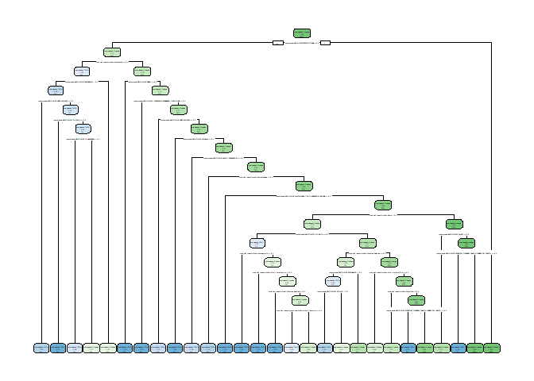

```r
tree_fit_tune %>%
    extract_fit_engine() %>%
    rpart.plot(roundint = FALSE)
```

```r
prediccion <- tibble(tipo_institucion_2 = "Universidades Privadas",
                     `area_del_conocimiento_Administración y Comercio` = "1",
                     area_del_conocimiento_Agropecuaria = "0",
                     `area_del_conocimiento_Arte y Arquitectura` = "0",
                     `area_del_conocimiento_Ciencias Básicas` = "0",
                     `area_del_conocimiento_Ciencias Sociales` = "0",
                     area_del_conocimiento_Derecho = "0",
                     area_del_conocimiento_Educación = "0",
                     area_del_conocimiento_Humanidades = "0",
                     area_del_conocimiento_Salud = "0",
                     area_del_conocimiento_Tecnología = "0",
                     `region_sede_REGION DE ANTOFAGASTA` = "0",
                     `region_sede_REGION DE ARICA Y PARINACOTA` = "0",
                     `region_sede_REGION DE ATACAMA` = "0",
                     `region_sede_REGION DE AYSEN DEL GENERAL CARLOS IBAÑEZ DEL CAMPO` = "0",
                     `region_sede_REGION DE COQUIMBO` = "0",
                     `region_sede_REGION DE LA ARAUCANIA` = "0",
                     `region_sede_REGION DE LOS LAGOS` = "0",
                     `region_sede_REGION DE LOS RIOS` = "0",
                     `region_sede_REGION DE MAGALLANES Y DE LA ANTARTICA CHILENA` = "0",
                     `region_sede_REGION DE ÑUBLE` = "0",
                     `region_sede_REGION DE TARAPACA` = "0",
                     `region_sede_REGION DE VALPARAISO` = "0",
                     `region_sede_REGION DEL BIOBIO` = "0",
                     `region_sede_REGION DEL LIBERTADOR BERNARDO OHIGGINS` = "0",
                     `region_sede_REGION DEL MAULE` = "0",
                     `region_sede_REGION METROPOLITANA` = "1")
prediccion
```